# IF240 - Machine Learning and deep learning

## TP1 - K-Means algorithm

By Aurélie Bugeau and Michaël Clément

Credits: Chris Piech and Andrew Ng

```python
import numpy as np
import matplotlib.pyplot as plt
%matplotlib inline
```

### 1. K-Means implementation

K-Means is an algorithm that takes aims at partitioning a given dataset into $k$ groups (called clusters) of data similar to each other. Each cluster is characterized by its centroid. In this practice, you are going to implement the K-Means algorithm and apply it on different datasets.

Read and understand the functions below. The `should_stop`, `get_labels` and `get_centroids` will be implemented afterwards.

```python
# Apply the k-means training algorithm
def kmeans(dataset, num_clusters, max_iterations=5):
    centroids = init_random_centroids(dataset, num_clusters)
    old_centroids = None
    iterations = 0
    while not should_stop(old_centroids, centroids, iterations, max_iterations):
        old_centroids = centroids
        iterations += 1
        labels = get_labels(dataset, centroids)
        centroids = get_centroids(dataset, labels, num_clusters)

    return centroids, labels

# Initialize centroids by choosing randomly k points from the dataset
def init_random_centroids(dataset, num_clusters):
    num_points = dataset.shape[0]
    random_indices = np.random.randint(num_points, size=num_clusters)
    random_centroids = dataset[random_indices, :]
    return random_centroids
```

**(Question)** Complete the following functions:

```python
# Returns True or False if k-means if the maximum number of iterations is reached
# or if the centroids do not change anymore (i.e. if the distance with the previous ones is very small)
def should_stop(old_centroids, centroids, iterations, max_iterations):
    if(iterations==max_iterations): return True
    if(old_centroids is None) : return False
    return np.allclose(old_centroids, centroids)
```

```python
def distance(centroid, point):
    d=0
    for i in range(centroid.shape[0]):
        d+=(centroid[i]-point[i])**2
    return np.sqrt(d)

# Returns the label for each point in the dataset in a NumPy array. The label is the index of the closest centroid
def get_labels(dataset, centroids):
    labels = np.empty(len(dataset))
    for i in range(len(dataset)):
        ind = 0
        d = distance(centroids[0],dataset[i])
        for j in range(len(centroids)):
            if(d>distance(centroids[j],dataset[i])):
                ind=j
                d=distance(centroids[j],dataset[i])
        labels[i] = ind
    return labels
```

```python
# Returns the centroids of the clusters.
# Each centroid is the geometric mean of the points that have that centroid's label.
# If a centroid is empty (no points have this centroid's label) you should randomly re-initialize it.

def get_centroids(dataset, labels, k):
    geo_mean = np.zeros([k,dataset.shape[1]])
    for i in range(k):
        bool_idx = (labels==i) # labels [1,2,1,3] -> pour labels==1 : bool_idx = [T,F,T,F]
        select = dataset[bool_idx] # garde uniquement les valeurs de dataset pour les index True
        if(select.size!=0): geo_mean[i] = np.mean(select, axis = 0)
    return geo_mean

#recherches : elbow, clustering hierarchique
```

### 2. Experiments on toy datasets

#### Simple data samples

**(Question)** Experiment and validate the method on a toy dataset. You can experiment with different values of $k$ and different toy data samples.

```python
x1 = np.array([1, 1])
x2 = np.array([2, 2])
x3 = np.array([3, 3])
x4 = np.array([4, 4])
X = np.vstack((x1, x2, x3, x4))
print(kmeans(X,4,5))
```

```
(array([[3., 3.],
       [2., 2.],
       [4., 4.],
       [1., 1.]]), array([3., 1., 0., 2.]))
```

**(Question)** Analyze and comment the results.

Nous avons 4 points. Si nous utilisons 4 clusters nous avons bien les coordonnées de chaque point dans la liste des coordonnées de centroides.

#### 2D Point Cloud

Now, we are going to test and plot the results on a 2D point cloud.

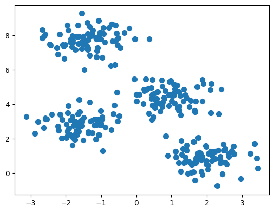

```python
# Dataset generation
from sklearn.datasets import make_blobs
X, y_true = make_blobs(n_samples=300, centers=4, cluster_std=0.60, random_state=0)
plt.scatter(X[:, 0], X[:, 1], s=50);
```

**(Question)** Apply K-Means on this point cloud and plot the results. Try different parameters for `make_blobs` and different parameters for the K-Means algorithm.

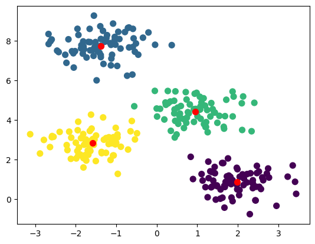

```python
# Apply K-Means
centroids, labels = kmeans(X,4)

# Plot the data samples with their labels
plt.scatter(X[:, 0], X[:, 1], c=labels, s=50, cmap='viridis')

# Plot the centers
plt.scatter(centroids[:, 0], centroids[:, 1], c='red', s=50)
```

**(Question)** Analyse and comment the results.

Les résultats sont cohérents. Nous avons 4 groupes de points, et avec 4 clusters, chaque groupement a une couleur differente et le centroid est bien au milieu de ce groupement.